# Genre DEMO:SVM Radial OneVsOne

try it: https://www.youtube.com/watch?v=h5dda-gRpVk

This is the demo for solve Genre problematic. In order to well understand it, this file was resumed to only show up the data partition and model test.

Considerations: - test set has a size of 30%; - train set has a size of 70%;

Strategies: - One vs One; - Supervised Classification;

Models: - SVM Radial; - SVM Linear; - KNN; - Naive Bayne;

Main goal of the best model: - Classify/Predict new instances using these models; - Find the must importance features; - Find the best model possible;

Vocabulary:

“discrete values” : ( Binary values like 0/1, yes/no, true/false )

‘formula’ :

The variable on the left-hand side of a tilde (~) is called the “dependent variable”(“response variable”, “outcome variable” or “label”), while the variables on the right-hand side are called the “independent variables” (“predictor (variable)”, “controlled variable”, “feature”) and are joined by plus signs +.

“+” : for adding terms; “-” : for removing terms;

References:

Music Map: https://musicmap.info/

Classification of Artist Genre through Supervised Learning http://cs229.stanford.edu/proj2016/report/RidleyDumovic-ClassificationOfArtistGenrethroughSupervisedLearning-report.pdf?fbclid=IwAR2WJEi8JdE2Ut_xwUe0WWZPFJUBxm16UE9vpkrXlnCF23Edeu2SMwzTQgU

SUPPORT VECTOR MACHINE CLASSIFIER IMPLEMENTATION IN R WITH CARET PACKAGE http://dataaspirant.com/2017/01/19/support-vector-machine-classifier-implementation-r-caret-package/

http://cs229.stanford.edu/proj2016/report/RidleyDumovic-ClassificationOfArtistGenrethroughSupervisedLearning-report.pdf?fbclid=IwAR2WJEi8JdE2Ut_xwUe0WWZPFJUBxm16UE9vpkrXlnCF23Edeu2SMwzTQgU

```r
library(dplyr)
library(quadprog)
library(sjlabelled)
#Load data
#genres = read.csv(file = '~/Documents/dp_datamining/data/dataGenre.csv', header = TRUE, na.strings = "?")
rockG = read.csv(file = '~/Documents/dp_datamining/data/rockG.csv', sep = ";", header = TRUE, na.strings = "?")
#popG = read.csv(file = '~/Documents/dp_datamining/data/popG.csv', sep = ";", header = TRUE, na.strings = "?")
#electronicG = read.csv(file = '~/Documents/dp_datamining/data/electronicG.csv', sep = ";", header = TRUE, na.strings = "?")
othersG = read.csv(file = '~/Documents/dp_datamining/data/othersG.csv', sep = ";", header = TRUE, na.strings = "?")
#Remove "tempo equals 0, because is not relevante for now."
rockG <- rockG[!rockG$tempo <= 45.0 & !rockG$tempo >= 250.0,]
#Remove column from this set
rockG$titlesong <- NULL
rockG$typegroup <- NULL
#rockG$duration <- NULL
#rockG$loudness <- NULL
#ockG$accoustiness <- NULL
#rockG$energy <- NULL
# rockG$Class[rockG$energy < 0.8] <- 0
# rockG$Class[rockG$energy >= 0.8] <- 1
#take a sample of genres "Others"
#Only 1% from attributes with the label Others
others_df <- rockG[ sample( which(rockG$genretype== "Others"), round(0.02*length(which(rockG$genretype== "Others")))), ]
rock_df <- rockG[which(rockG$genretype=='Rock'),]
#Reattach A small and random data set with Others
rock_df <- bind_rows(others_df,rock_df)
summary(rock_df)
```

```
  genretype       tempo           energy          danceability
 Others:885   Min.   : 50.0   Min.   :0.000269   Min.   :0.0640
 Rock  :562   1st Qu.: 96.0   1st Qu.:0.386000   1st Qu.:0.4000
              Median :119.0   Median :0.633000   Median :0.5460
              Mean   :118.9   Mean   :0.589780   Mean   :0.5293
              3rd Qu.:137.0   3rd Qu.:0.835000   3rd Qu.:0.6685
              Max.   :204.0   Max.   :0.998000   Max.   :0.9560
  speechiness       accoustiness          loudness
 Min.   :0.02230   Min.   :0.0000011   Min.   :-51.065
 1st Qu.:0.03525   1st Qu.:0.0189000   1st Qu.:-11.650
 Median :0.04550   Median :0.1890000   Median : -7.504
 Mean   :0.07778   Mean   :0.3510916   Mean   : -9.570
 3rd Qu.:0.07780   3rd Qu.:0.7040000   3rd Qu.: -5.466
 Max.   :0.96500   Max.   :0.9960000   Max.   : -0.657
    duration          valence       instrumentalness
 Min.   :  16133   Min.   :0.0000   Min.   :0.0000000
 1st Qu.: 189952   1st Qu.:0.1905   1st Qu.:0.0000018
 Median : 225387   Median :0.3970   Median :0.0011900
 Mean   : 246639   Mean   :0.4203   Mean   :0.2104989
 3rd Qu.: 268012   3rd Qu.:0.6355   3rd Qu.:0.3370000
 Max.   :1349680   Max.   :0.9860   Max.   :0.9850000
```

```r
str(rock_df)
```

```
'data.frame':   1447 obs. of  10 variables:
 $ genretype       : Factor w/ 2 levels "Others","Rock": 1 1 1 1 1 1 1 1 1 1 ...
 $ tempo           : int  160 75 120 99 81 100 104 126 128 129 ...
 $ energy          : num  0.421 0.882 0.587 0.784 0.634 0.976 0.49 0.619 0.951 0.714 ...
 $ danceability    : num  0.616 0.426 0.665 0.498 0.641 0.429 0.54 0.639 0.704 0.817 ...
 $ speechiness     : num  0.0333 0.0652 0.035 0.067 0.0359 0.057 0.0298 0.0343 0.0553 0.237 ...
 $ accoustiness    : num  0.214 0.0164 0.151 0.0111 0.142 0.00167 0.845 0.173 0.0145 0.0548 ...
 $ loudness        : num  -12.71 -3.26 -8.01 -5.41 -4.39 ...
 $ duration        : num  236907 179453 286587 164707 221040 ...
 $ valence         : num  0.203 0.634 0.0924 0.456 0.469 0.239 0.893 0.227 0.839 0.388 ...
 $ instrumentalness: num  8.33e-01 0.00 3.40e-01 1.58e-03 8.95e-05 4.85e-02 1.13e-04 0.00 1.19e-05 0.00 ...
```

```r
class(rock_df)
```

```
[1] "data.frame"
```

```r
#summary(others_df)
# summary(rockG)
# class(rockG)
#Reattach A small and random data set with Others
#rock_df <- bind_rows(rockG,others_df)
#rock_df <- data.frame(others_df,rockG)
#summary(rock_df$genretype)
# #Data Preparation
# #Remove lyrics from this set
# #genres$titlesong <- NULL
# #Remove "tempo equals 0, because is not relevante for now."
# genres <- genres[!genres$tempo <= 45.0 & !genres$tempo >= 250.0,]
# #Remove "Others from type of group, because is not relevante now."
# genres <- genres[!genres$typegroup == "Others",]
# genres$titlesong <- NULL
# genres$typegroup <- NULL
#
# #genres$Category[genres$genretype=='Others'] <- 0
# #genres$Category[genres$genretype=='Rock'] <- 1
#
# rock_df <-genres[which(genres$genretype=='Rock'),] # genres[is.element(genres$genretype,'Rock' ),] filter(genres, genres$genretype %in% 'Rock') #
#
#
#
#
#
#
#
# pop_df <- genres[which(genres$genretype=='Pop'),]
# Electronic_df <- genres[which(genres$genretype=='Electronic'),]
#take a sample of genres "Others"
#Only 2% from attributes with the label Others
#others_df <- genres[sample(which(genres$genretype=='Others'),size = 0.02* nrow(genres[which(genres$genretype=='Others'),]) ), ]
#others_df$genretype<-factor(others_df$genretype)
#others_df <- droplevels(others_df)
#dataset without the label Others
#For any case
# dataset_withoutOthers <- genres[!genres$genretype=='Others',]
# summary(dataset_withoutOthers$genretype)
# #Reattach A small and random data set with Others
# rock_df <- bind_rows(others_df,rock_df)
# #rock_df <- remove_labels(rock_df$genretype, labels = 'Blues')
#
# rock_df <- droplevels(rock_df)
# rock_df <- transform(rock_df, genretype = factor(genretype, labels = "Rock"))
# rock_df <- subset(rock_df, genretype != "Rock")
# table(rock_df$genretype)
# table(droplevels(rock_df)$genretype)
#
#1: Others
#2: Rock
#summary(rock_df$genretype)
#print(rock_df)
```

```r
library(caret)
```

[output not shown]

```r
library(lattice)
library(ggplot2)
# #One vs One: Rock
# # Split between 80 and 30
# #index_Rock <- sample(1:nrow(rock_df),size = 0.7* nrow(rock_df))
# index_Rock <- createDataPartition(y = rock_df$genretype, p= 0.7, list = FALSE)
# # Use the large partition to training - 70
# train_Rock <- rock_df[index_Rock,]
# # Use the small partition to test - 30
# test_Rock <- rock_df[-index_Rock,]
#
# train_Rock <- train_Rock[which(!train_Rock$genretype=='NA'),]
# str(train_Rock)
# summary(train_Rock)
# str(train_Rock)
# class(train_Rock)
#
# test_Rock <- test_Rock[which(!test_Rock$genretype=='NA'),]
# str(test_Rock)
# summary(test_Rock)
# str(test_Rock)
# class(test_Rock)
library("splitstackshape")
test<-stratified(rock_df,"genretype", size=.3)
train_Rock<-setdiff(rock_df,test)
train_Rock <- train_Rock[which(!train_Rock$genretype=='NA'),]
summary(train_Rock)
```

```
  genretype       tempo           energy          danceability
 Others:619   Min.   : 50.0   Min.   :0.000269   Min.   :0.0701
 Rock  :393   1st Qu.: 96.0   1st Qu.:0.384750   1st Qu.:0.3972
              Median :120.0   Median :0.632500   Median :0.5460
              Mean   :119.6   Mean   :0.586363   Mean   :0.5252
              3rd Qu.:138.0   3rd Qu.:0.829500   3rd Qu.:0.6650
              Max.   :204.0   Max.   :0.997000   Max.   :0.9280
  speechiness       accoustiness          loudness
 Min.   :0.02480   Min.   :0.0000011   Min.   :-51.065
 1st Qu.:0.03550   1st Qu.:0.0202750   1st Qu.:-11.778
 Median :0.04575   Median :0.1960000   Median : -7.552
 Mean   :0.07766   Mean   :0.3550660   Mean   : -9.711
 3rd Qu.:0.07497   3rd Qu.:0.7140000   3rd Qu.: -5.424
 Max.   :0.96500   Max.   :0.9960000   Max.   : -0.657
    duration          valence       instrumentalness
 Min.   :  20587   Min.   :0.0000   Min.   :0.0000000
 1st Qu.: 189364   1st Qu.:0.1928   1st Qu.:0.0000025
 Median : 225134   Median :0.3980   Median :0.0015750
 Mean   : 245225   Mean   :0.4205   Mean   :0.2105873
 3rd Qu.: 269207   3rd Qu.:0.6415   3rd Qu.:0.3377500
 Max.   :1349680   Max.   :0.9710   Max.   :0.9850000
```

```r
summary(train_Rock$genretype)
```

```
Others   Rock
   619    393
```

```r
test_Rock <- test[which(!test$genretype=='NA'),]
summary(test_Rock)
```

```
  genretype       tempo           energy         danceability
 Others:266   Min.   : 56.0   Min.   :0.00706   Min.   :0.0640
 Rock  :169   1st Qu.: 97.5   1st Qu.:0.38750   1st Qu.:0.4155
              Median :117.0   Median :0.63500   Median :0.5460
              Mean   :117.4   Mean   :0.59773   Mean   :0.5388
              3rd Qu.:134.0   3rd Qu.:0.83800   3rd Qu.:0.6730
              Max.   :200.0   Max.   :0.99800   Max.   :0.9560
  speechiness       accoustiness          loudness
 Min.   :0.02230   Min.   :0.0000017   Min.   :-38.896
 1st Qu.:0.03500   1st Qu.:0.0145000   1st Qu.:-11.276
 Median :0.04490   Median :0.1740000   Median : -7.407
 Mean   :0.07805   Mean   :0.3418456   Mean   : -9.244
 3rd Qu.:0.08350   3rd Qu.:0.6845000   3rd Qu.: -5.562
 Max.   :0.86300   Max.   :0.9950000   Max.   : -1.355
    duration          valence       instrumentalness
 Min.   :  16133   Min.   :0.0324   Min.   :0.0000000
 1st Qu.: 191887   1st Qu.:0.1870   1st Qu.:0.0000011
 Median : 226475   Median :0.3970   Median :0.0006260
 Mean   : 249929   Mean   :0.4198   Mean   :0.2102933
 3rd Qu.: 265466   3rd Qu.:0.6245   3rd Qu.:0.2725000
 Max.   :1189090   Max.   :0.9860   Max.   :0.9740000
```

```r
library(caret)
library(lattice)
library(ggplot2)
library(klaR)
library(MASS)
# Run algorithms using 10-fold cross validation
control <- trainControl(method="cv", number=10)
metric <- "Accuracy"
#+tempo+energy+danceability+speechiness+accoustiness+loudness+duration+valence+instrumentalness
formula_SVM <- genretype~ .
#SVM Linear
set.seed(89)
fit.svmLinear_train <- train(formula_SVM,
                             data = train_Rock,
                             method = "svmLinear",
                             trControl=control,
                             preProcess = c("center", "scale"),
                             tuneLength = 10)
fit.svmLinear_train
```

```
Support Vector Machines with Linear Kernel

1012 samples
   9 predictor
   2 classes: 'Others', 'Rock'

Pre-processing: centered (9), scaled (9)
Resampling: Cross-Validated (10 fold)
Summary of sample sizes: 911, 911, 910, 911, 911, 911, ...
Resampling results:

  Accuracy   Kappa
  0.6116676  0

Tuning parameter 'C' was held constant at a value of 1
```

```r
#plot(fit.svmLinear_train)
#SVM Radial
set.seed(89)
fit.svmRadial_train <- train(formula_SVM,
                             data = train_Rock,
                             method = "svmRadial",
                             gamma=1,
                             trControl=control,
                             preProcess = c("center", "scale"),
                             tuneLength = 10)
fit.svmRadial_train
```

```
Support Vector Machines with Radial Basis Function Kernel

1012 samples
   9 predictor
   2 classes: 'Others', 'Rock'

Pre-processing: centered (9), scaled (9)
Resampling: Cross-Validated (10 fold)
Summary of sample sizes: 911, 911, 910, 911, 911, 911, ...
Resampling results across tuning parameters:

  C       Accuracy   Kappa
    0.25  0.6057465  0.007355281
    0.50  0.6166570  0.093962469
    1.00  0.6157154  0.121179875
    2.00  0.6147059  0.138131209
    4.00  0.6166473  0.151081369
    8.00  0.6008639  0.123009376
   16.00  0.5909823  0.115254679
   32.00  0.5820811  0.116843056
   64.00  0.5682392  0.096395670
  128.00  0.5642691  0.090157902

Tuning parameter 'sigma' was held constant at a value of 0.1417622
Accuracy was used to select the optimal model using the largest value.
The final values used for the model were sigma = 0.1417622 and C = 0.5.
```

```r
#plot(fit.svmRadial_train)
#KNN
set.seed(89)
fit.knn_train <- train(formula_SVM,
                             data = train_Rock,
                             method = "knn",
                             trControl=control,
                             preProcess = c("center", "scale"),
                             tuneLength = 10)
fit.knn_train
```

```
k-Nearest Neighbors

1012 samples
   9 predictor
   2 classes: 'Others', 'Rock'

Pre-processing: centered (9), scaled (9)
Resampling: Cross-Validated (10 fold)
Summary of sample sizes: 911, 911, 910, 911, 911, 911, ...
Resampling results across tuning parameters:

  k   Accuracy   Kappa
   5  0.5869734  0.10908069
   7  0.5731217  0.06893980
   9  0.5899049  0.10106925
  11  0.5908659  0.09356390
  13  0.5988449  0.10953729
  15  0.5959134  0.09920356
  17  0.5948942  0.09590465
  19  0.5997864  0.10175558
  21  0.6046787  0.11412376
  23  0.6026985  0.11099652

Accuracy was used to select the optimal model using the largest value.
The final value used for the model was k = 21.
```

```r
#plot(fit.knn_train)
#NaiveBayne
set.seed(89)
fit.nb_train <- train(formula_SVM,
                             data = train_Rock,
                             method = "nb",
                             trControl=control,
                             preProcess = c("center", "scale"),
                             tuneLength = 10)
```

[output not shown]

```r
fit.nb_train
```

```
Naive Bayes

1012 samples
   9 predictor
   2 classes: 'Others', 'Rock'

Pre-processing: centered (9), scaled (9)
Resampling: Cross-Validated (10 fold)
Summary of sample sizes: 911, 911, 910, 911, 911, 911, ...
Resampling results across tuning parameters:

  usekernel  Accuracy   Kappa
  FALSE      0.5444477  0.1386776
   TRUE      0.5335372  0.1043841

Tuning parameter 'fL' was held constant at a value of 0
Tuning
 parameter 'adjust' was held constant at a value of 1
Accuracy was used to select the optimal model using the largest value.
The final values used for the model were fL = 0, usekernel = FALSE
 and adjust = 1.
```

```r
#plot(fit.nb_train)
# summarize accuracy of models
results <- resamples(list(svmLinear=fit.svmLinear_train,
                          #mxnet=fit.mxnet_train,
                          nb=fit.nb_train,
                          knn=fit.knn_train,
                          svmRadial=fit.svmRadial_train))
summary(results)
```

```
Call:
summary.resamples(object = results)

Models: svmLinear, nb, knn, svmRadial
Number of resamples: 10

Accuracy
               Min.   1st Qu.    Median      Mean   3rd Qu.      Max.
svmLinear 0.6039604 0.6093477 0.6138614 0.6116676 0.6138614 0.6138614
nb        0.4455446 0.5011891 0.5544554 0.5444477 0.5841584 0.6237624
knn       0.5346535 0.5816832 0.6059018 0.6046787 0.6287129 0.6666667
svmRadial 0.5841584 0.5896913 0.6188119 0.6166570 0.6311881 0.6633663
          NA's
svmLinear    0
nb           0
knn          0
svmRadial    0

Kappa
                  Min.    1st Qu.     Median       Mean   3rd Qu.
svmLinear  0.000000000 0.00000000 0.00000000 0.00000000 0.0000000
nb        -0.058779483 0.07334346 0.15748296 0.13867757 0.2081329
knn       -0.015401070 0.06272483 0.11847379 0.11412376 0.1522539
svmRadial -0.006578947 0.05371467 0.09942341 0.09396247 0.1206140
               Max. NA's
svmLinear 0.0000000    0
nb        0.2815425    0
knn       0.2401402    0
svmRadial 0.1879164    0
```

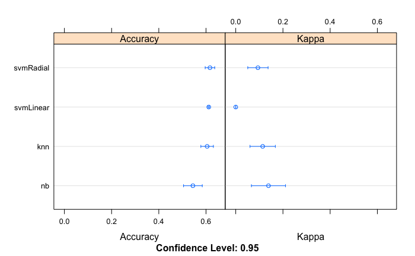

```r
# compare accuracy of models
dotplot(results)
```

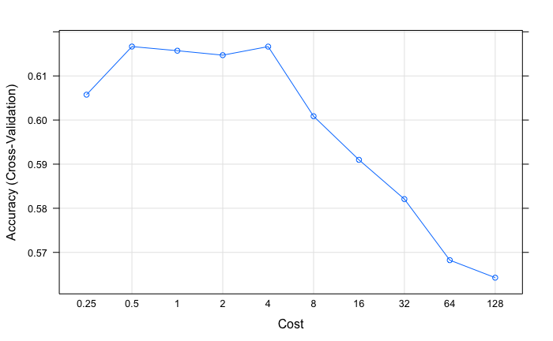

```r
plot(fit.svmRadial_train,
     plotType = "line",
     metric = "Accuracy")
```

```r
# estimate variable importance
importance <- varImp(fit.svmRadial_train, scale=FALSE)
# summarize importance
print(importance)
```

```
ROC curve variable importance
```

|  | Importance |
| --- | --- |
| accoustiness | 0.6161687 |
| energy | 0.5915476 |
| loudness | 0.5819306 |
| duration | 0.5319998 |
| valence | 0.5248020 |
| tempo | 0.5147102 |
| speechiness | 0.5042649 |
| danceability | 0.5032290 |
| instrumentalness | 0.5001870 |

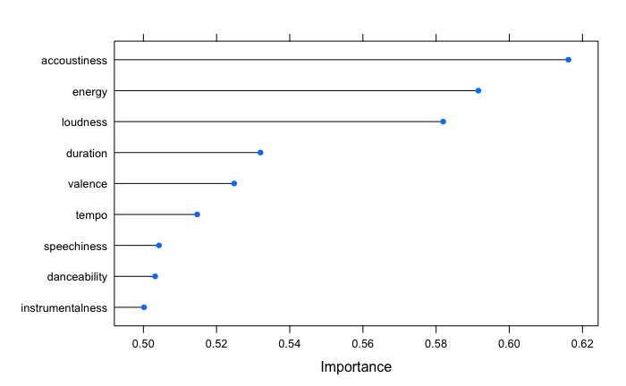

```r
# plot importance
plot(importance)
```

```r
library(MASS)
library(plot3D)
#Choose the best model
bestModel <- fit.svmRadial_train
test_pred <- predict(bestModel, newdata = test_Rock)
confusionMatrix(test_pred, test_Rock$genretype )
```

```
Confusion Matrix and Statistics

          Reference
Prediction Others Rock
    Others    233  128
    Rock       33   41

               Accuracy : 0.6299
                 95% CI : (0.5826, 0.6754)
    No Information Rate : 0.6115
    P-Value [Acc > NIR] : 0.2309

                  Kappa : 0.1321
 Mcnemar's Test P-Value : 1.28e-13

            Sensitivity : 0.8759
            Specificity : 0.2426
         Pos Pred Value : 0.6454
         Neg Pred Value : 0.5541
             Prevalence : 0.6115
         Detection Rate : 0.5356
   Detection Prevalence : 0.8299
      Balanced Accuracy : 0.5593

       'Positive' Class : Others
```

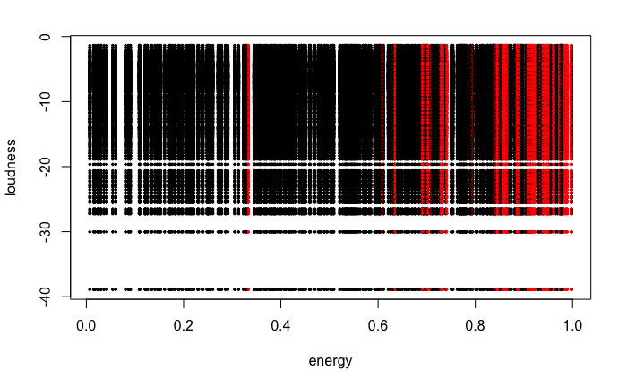

```r
xgrid=expand.grid(energy=test_Rock$energy,loudness=test_Rock$loudness)  #generating grid points
#lets plot the non linear decision boundary
plot(xgrid,col=as.numeric(test_pred),pch=20,cex=0.5)
points(test_Rock$genretype,pch=19)
```

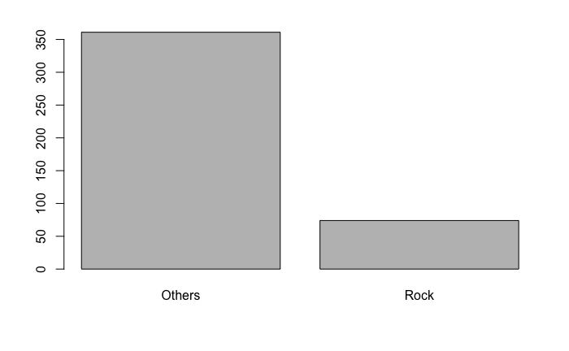

```r
plot(test_pred)
```

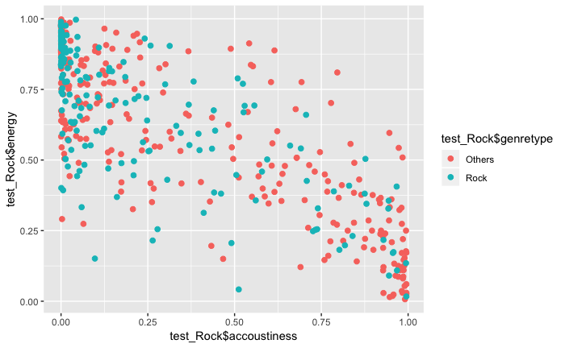

```r
p=ggplot(test_Rock,
         aes(y=test_Rock$energy,
             x=test_Rock$accoustiness,
             color=test_Rock$genretype ))
p+geom_point(size=2)
```

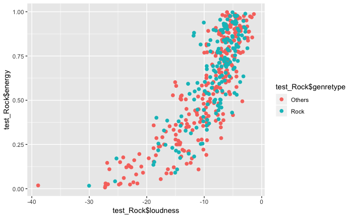

```r
p=ggplot(test_Rock,
         aes(y=test_Rock$energy,
             x=test_Rock$loudness,
             color=test_Rock$genretype ))
p+geom_point(size=2)
```

```r
summary(test_pred)
```

```
Others   Rock
   361     74
```

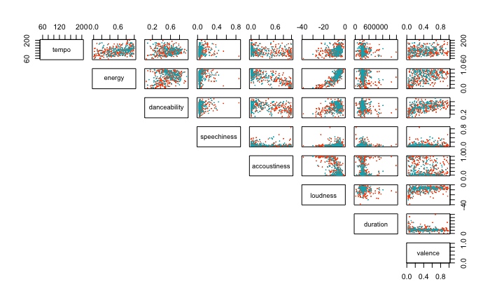

```r
my_cols <- c("#FC4E07","#00AFBB")
pairs(test_Rock[,2:9], pch = 20,  cex = 0.1,
      col = my_cols[test_Rock$genretype],
      lower.panel=NULL)
```

```r
summary(test_pred)
```

```
Others   Rock
   361     74
```

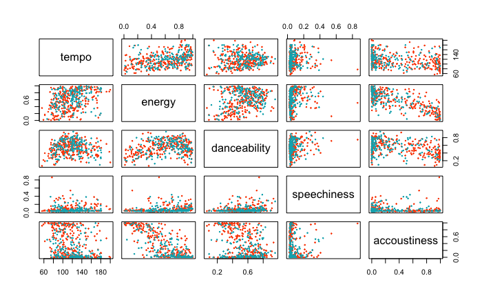

```r
my_cols <- c("#FC4E07","#00AFBB")
pairs(test_Rock[,2:6], pch = 20,  cex = 0.4,
      col = my_cols[test_Rock$genretype])
```

```r
#Trying predict what song in other maybe is Rock
summary(others_df$genretype)
```

```
Others   Rock
   885      0
```

```r
pred <- predict(bestModel, newdata = others_df)
confusionMatrix(pred,others_df$genretype )
```

```
Confusion Matrix and Statistics

          Reference
Prediction Others Rock
    Others    796    0
    Rock       89    0

               Accuracy : 0.8994
                 95% CI : (0.8777, 0.9185)
    No Information Rate : 1
    P-Value [Acc > NIR] : 1

                  Kappa : 0
 Mcnemar's Test P-Value : <2e-16

            Sensitivity : 0.8994
            Specificity :     NA
         Pos Pred Value :     NA
         Neg Pred Value :     NA
             Prevalence : 1.0000
         Detection Rate : 0.8994
   Detection Prevalence : 0.8994
      Balanced Accuracy :     NA

       'Positive' Class : Others
```

```r
#Trying to predict what song in other maybe is Rock. Doing that with a dataset of 50% others.
others_df2 <- rockG[ sample( which(rockG$genretype== "Others"), round(0.5*length(which(rockG$genretype== "Others")))), ]
others_df2$titlesong <- NULL
others_df2$typegroup <- NULL
#Reattach A small and random data set with Others
tes_df2 <- bind_rows(others_df,rockG[which(rockG$genretype=='Rock'),])
str(tes_df2)
```

```
'data.frame':   1447 obs. of  10 variables:
 $ genretype       : Factor w/ 2 levels "Others","Rock": 1 1 1 1 1 1 1 1 1 1 ...
 $ tempo           : int  160 75 120 99 81 100 104 126 128 129 ...
 $ energy          : num  0.421 0.882 0.587 0.784 0.634 0.976 0.49 0.619 0.951 0.714 ...
 $ danceability    : num  0.616 0.426 0.665 0.498 0.641 0.429 0.54 0.639 0.704 0.817 ...
 $ speechiness     : num  0.0333 0.0652 0.035 0.067 0.0359 0.057 0.0298 0.0343 0.0553 0.237 ...
 $ accoustiness    : num  0.214 0.0164 0.151 0.0111 0.142 0.00167 0.845 0.173 0.0145 0.0548 ...
 $ loudness        : num  -12.71 -3.26 -8.01 -5.41 -4.39 ...
 $ duration        : num  236907 179453 286587 164707 221040 ...
 $ valence         : num  0.203 0.634 0.0924 0.456 0.469 0.239 0.893 0.227 0.839 0.388 ...
 $ instrumentalness: num  8.33e-01 0.00 3.40e-01 1.58e-03 8.95e-05 4.85e-02 1.13e-04 0.00 1.19e-05 0.00 ...
```

```r
summary(tes_df2$genretype)
```

```
Others   Rock
   885    562
```

```r
#Then to double check, we create a second set that containts others and rock genre.
othersG_pred <- predict(bestModel, newdata = tes_df2)
confusionMatrix(othersG_pred, tes_df2$genretype )
```

```
Confusion Matrix and Statistics

          Reference
Prediction Others Rock
    Others    796  428
    Rock       89  134

               Accuracy : 0.6427
                 95% CI : (0.6174, 0.6674)
    No Information Rate : 0.6116
    P-Value [Acc > NIR] : 0.007963

                  Kappa : 0.1549
 Mcnemar's Test P-Value : < 2.2e-16

            Sensitivity : 0.8994
            Specificity : 0.2384
         Pos Pred Value : 0.6503
         Neg Pred Value : 0.6009
             Prevalence : 0.6116
         Detection Rate : 0.5501
   Detection Prevalence : 0.8459
      Balanced Accuracy : 0.5689

       'Positive' Class : Others
```